# Introduction

Billie Anderson, Mark Newman

2020-09-11

# Agenda

- Welcome
- Class overview
- What is Categorical Data?

# Welcome to ANLY 545

- The course will focus on the fundamentals of analyzing categorical data.
- The first question we must ask ourselves is - **What is Categorical Data?**

# What is Categorical Data?

A *categorical variable* is one for which the possible measured or assigned values consist of of a discrete set of categories, which may be ordered or unordered. Some typical examples are:

- Gender, with categories “Male,” “Female.”
- Marital status, with categories “Never married,” “Married,” “Separated,” “Divorced,” “Widowed.”
- Side effects (in a pharmacological study), with categories “None,” “Skin rash,” “Sleep disorder,” “Anxiety.”
- Political attitude, with categories “Left,” “Center,” “Right.”
- Party preference (in Canada), with categories “NDP,” “Liberal,” “Conservative,” “Green.”
- Treatment outcome, with categories “no improvement,” “some improvement,” or “marked improvement.”
- Age, with categories “0-9,” “10-19,” “20-29,” “30-39,” etc…
- Number of children, with categories 0, 1, 2, etc..

# Different Types of Categorical Variables

- As the previous examples illustrate, categorical variables can have a varying number of different categories.
- Different terminology to used to distinguish the number of categories.

*-* *Binary variables* (or *dichotomous variables*) is used to refer to a categorical variable with two levels.

*-* *Polytomous variables* is used to refer to a categorical variable with more than two levels.

# Example

# Measurement Levels for Categorical Variables

Some categorical variables (grade you receive in this class; A, B, C, F) may have ordered categories (and are called *ordinal variables*), while others (*nominal variables*) like Marital status have unordered categories.

# Example

Table 1.2 shows a 2x2x3 table of ordered outcomes (“none,” “some,” or “marked” improvement) to an active treatment for rheumatoid arthritis compared to a placebo for men and women.

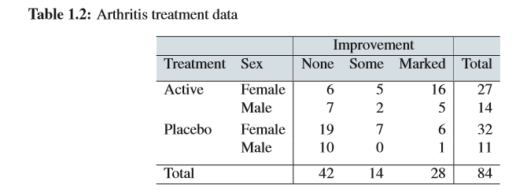

# Case Form versus Frequency Form

*Case form* means the data is in it’s raw form, data that is at the indivdiual level. Any individual/subject can be tracked back to it’s individual data record.

```r
head(vcd::Arthritis, n = 5)
```

```
##   ID Treatment  Sex Age Improved
## 1 57   Treated Male  27     Some
## 2 46   Treated Male  29     None
## 3 77   Treated Male  30     None
## 4 17   Treated Male  32   Marked
## 5 36   Treated Male  46   Marked
```

# Case Form versus Frequency Form (cont.)

Data in *frequency form* has already been tabulated, by counting over the categories of the table variables. The same data shown as a table in Table 1.2 appear in frequency form as shown below.

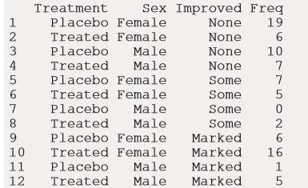

- An observation in a data set in frequency form refers to all cases in the cell collectively, and these cannot be identified individually.
- Data in case form can always be reduced to frequency form, but the reverse is rarely possible.

# Univariate, Bivariate, and Multivariate Data

- Univariate refers to one variable.
- Bivariate refers to two variables.

Multivariate refers to more than two variables. Table 1.2 is an example of a multivariate *contingency table*.

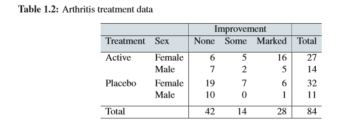

# Explanatory vs. Response Variables

- The *response variable* is the dependent (Y) variable that we are interested in modeling.
- The *explanatory variable* are the independent (X’s) or predictor variables help explain the *response variable*.
- When the *response variable* is categorical, we cannot use our classic linear models like regression and ANOVA. Many of the assumptions of those models are not met when the *response variable* is categorical.

So, when the *response variable* is categorical, we use categorical data techniques to perform standard statistical analyses like hypothesis testing and modeling (two main focal points of this class).

# Strategies for Categorical Data Analysis

Two main methods we will be using in this class; hypothesis testing and model building.

# Hypothesis Testing Approaches

Hypothesis testing’s main purpose is to determine if there is an *association* between two variables.

If there is evidence for an association, we can assess its strength by a variety of measures, including the difference in proportions admitted for men and women or the ratio of the odds of admission for men compared to women.

Another example on p. 8 of about the efficacy of the treatment for rheumatoid arthritis using associations among categorical variables; please read

# Specific Test for Hypothesis Testing

- Pearson Chi-square test
- Cramer’s V test
- Cochran Mantel-Haenszel test

# Mosiac Displays

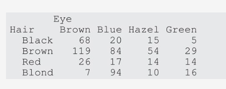

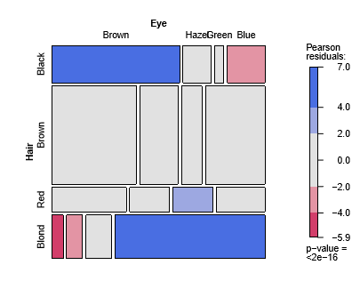

# Model Building Approaches

Model-building does involve hypothesis testing.

In this class, we are going to focus on logistic regression (appropriate when the response variable is binary).

Logistic regression using a logit function.

In logistic regression, you are modeling a function of the probability of response, denoted as $\pi$.

Logistic regression models the *log odds*.

$logit(\pi)=\log(\frac{\pi}{1-\pi})$.

The logistic regression model is given by: $logit(\pi)=\beta_0+\beta_1x_{1}+\beta_2x_{2}+...$

There are hypothesis testing procedures testing if there is an association among the response variable and the explanatory variables (the X’s). The hypothesis tests invlove testing whether the $\beta$ ’s are statistically different from 0.

A big advantage is that you can compute *odds ratios* (different from log odds!) that assist us in interpreting the model.